# Simulating traits with different genetic architectures

Jinguo Huang

2023-01-12

We’d like to simulate two traits with different genetic architectures: (1) with large genetic mean difference (could be a result of divergent selection); (2) with no or very small genetic mean difference (could be a result of stabilizing selection). Such that, we can simulate traits varying the LD contribution with same FST at causal loci.

For better replicability of the simulation, random seeds are fixed for the two traits in our simulation.

Here is the tutorial for how to find those seeds.

If you have different settings for the simulation, such as the number of causal alleles, desired FST, etc., the seeds need to be updated for simulating traits mentioned above.

In our simulation, seed1 is for frequency and beta, seed2 is for traits: sign distribution for beta, seed3 is for admixed simulation.

#### Step0: set up the parameters

```r
# load my functions
source("main_admix.R")

##############initialize################
fst = 0.2
nloci = 1e3
p_sel = 0 #selection strength
n = 1e4
P = 0
t = 20
m1 = 0 # HI
m2 = 0 # one directional CFG
theta = 0.5
pi=theta
```

#### Step1: find seed1

Let’s find seed1, seeds for vbetween.genic distribution, this will be the final (1.2) in the simulation. We want to find a seed with large vbetween.genic.

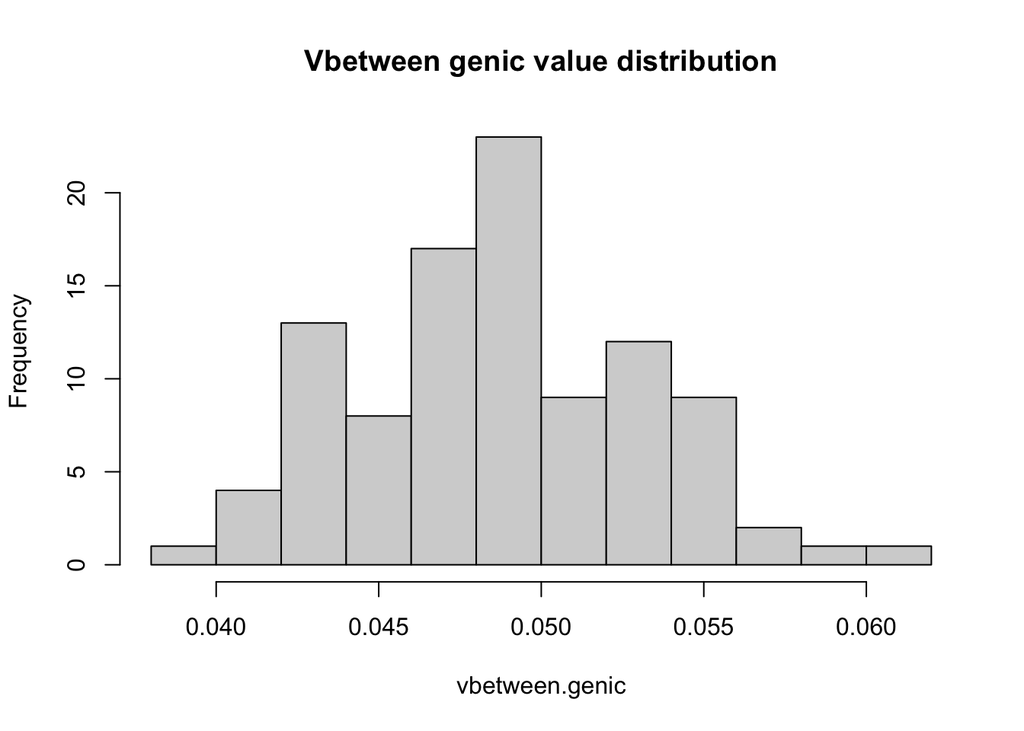

```r
# create an empty matrix for storage
seed_freq = matrix(NA, nrow = 100, ncol = 2)
for (seed1 in 1:100){
################### simulate parental groups genotype  ########################
#print("simulate parental groups genotype")
set.seed(seed1) # keep this part same across P

# Draw allele frequency in an ancestral population prior to the divergence
# and drawn from a uniform distribution unif(0.001,0.999)
anc.frq <- runif(nloci, min=1e-3, max=0.999)

#set freq per ancestral population at each locus, given fst and human ancestral allele maf
f1 <- rep(NA, nloci)
f2 <- rep(NA, nloci)
for (s in 1:nloci) {
  # set allele frequencies for ancestries
  p.pop1 <- 0
  p.pop2 <- 0
  anc.frq <- runif(1, min=1e-3, max=0.999)
  #Balding-Nichol model, also make sure 0.01<frq<0.99, so rare variants are avoided
  while((p.pop1 <= 0.01 || p.pop1 >= 0.99) || p.pop2 <= 0.01 || p.pop2 >= 0.99){
    p.pop1 <- rbeta(1, anc.frq*(1-fst)/fst,(1-anc.frq)*(1-fst)/fst)
    p.pop2 <- rbeta(1, anc.frq*(1-fst)/fst,(1-anc.frq)*(1-fst)/fst)
  }
  f1[s] <- p.pop1
  f2[s] <- p.pop2
}
fbar = (f1+f2)/2
fdiff = f1 - f2 #freq difference

# simulate parental genotype based on frequency
geno1 <- matrix(rbinom(nloci*n, 2, f1), byrow=T, nrow=n, ncol=nloci)
geno2 <- matrix(rbinom(nloci*n, 2, f2), byrow=T, nrow=n, ncol=nloci)

###################  simulate effect size  ########################
#print("simulate effect size")

# Choose effect sizes from the standard normal distribution N(0, 1/2*f*(1-f))
bg = matrix(
  rnorm(nloci, 0, sd = sqrt(1/(2*nloci*fbar*(1-fbar)))),
  nrow = nloci, ncol = 1)

#standardize to remove stochasticity in realized values
bg = ((bg - mean(bg)) / sd(bg)) * sqrt(1/(2*nloci*fbar*(1-fbar)))

# record vbetween genic
vbetween.genic = sum( bg^2 * (f1-f2)^2) * 2 * 0.5 * 0.5
seed_freq[seed1,1]=seed1
seed_freq[seed1,2]=vbetween.genic
}

# distribution of vbetween genic
hist(seed_freq[,2],
     main="Vbetween genic value distribution",
     xlab="vbetween.genic")
```

```r
# find the largest one, this will be the final (1.2) in the simulation
which(seed_freq == max(seed_freq[,2]), arr.ind = TRUE) #99   2
```

```
##      row col
## [1,]  99   2
```

```r
# what's the value of the final (1.2)?
seed_freq[99,2] #0.06022987
```

```
## [1] 0.06022987
```

Here, we set seed1=99.

#### Step2: find seed2

Let’s find seed2, to decide the distribution of signs of beta, such that we have the LD distribution to choose the largest and smallest LD contribution.

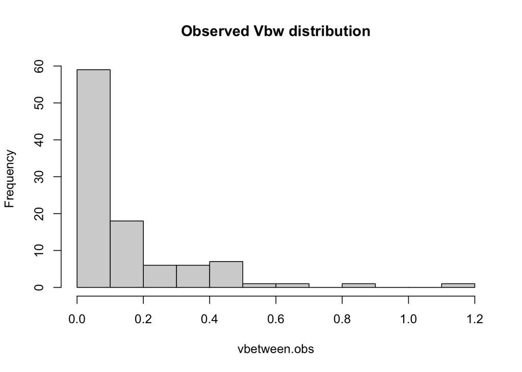

```r
seed1=99 #seed for freq
set.seed(seed1) # keep this part same across P

# Draw allele frequency in an ancestral population prior to the divergence
# and drawn from a uniform distribution unif(0.001,0.999)
anc.frq <- runif(nloci, min=1e-3, max=0.999)

#set freq per ancestral population at each locus, given fst and human ancestral allele maf
f1 <- rep(NA, nloci)
f2 <- rep(NA, nloci)
for (s in 1:nloci) {
  # set allele frequencies for ancestries
  p.pop1 <- 0
  p.pop2 <- 0
  anc.frq <- runif(1, min=1e-3, max=0.999)
  #Balding-Nichol model, also make sure 0.01<frq<0.99, so rare variants are avoided
  while((p.pop1 <= 0.01 || p.pop1 >= 0.99) || p.pop2 <= 0.01 || p.pop2 >= 0.99){
    p.pop1 <- rbeta(1, anc.frq*(1-fst)/fst,(1-anc.frq)*(1-fst)/fst)
    p.pop2 <- rbeta(1, anc.frq*(1-fst)/fst,(1-anc.frq)*(1-fst)/fst)
  }
  f1[s] <- p.pop1
  f2[s] <- p.pop2
}
fbar = (f1+f2)/2
#fbar = pi*f1 + (1-pi)*f2
fdiff = f1 - f2 #freq difference

# simulate parental genotype based on frequency
geno1 <- matrix(rbinom(nloci*n, 2, f1), byrow=T, nrow=n, ncol=nloci)
geno2 <- matrix(rbinom(nloci*n, 2, f2), byrow=T, nrow=n, ncol=nloci)

###################  simulate effect size  ########################
#print("simulate effect size")

# Choose effect sizes from the standard normal distribution N(0, 1/2*f*(1-f))
bg = matrix(
  rnorm(nloci, 0, sd = sqrt(1/(2*nloci*fbar*(1-fbar)))),
  nrow = nloci, ncol = 1)

#standardize to remove stochasticity in realized values
bg = ((bg - mean(bg)) / sd(bg)) * sqrt(1/(2*nloci*fbar*(1-fbar)))

# create an empty matrix for storage
seed_vbw = matrix(NA, nrow = 100, ncol = 4)
for (seed2 in 1:100){
# random assign sign to each bg such that we have different distribution
set.seed(seed2)
bg_sign=sample(c(-1,1), nloci, replace=T) #for controling beta sign disribution

# For some fraction p of the loci, choose the effect direction to be such that
# the allele that is more frequent in population 1 has a positive effect.
# The rest are random.
# weak selection, use prob f1/(f1+f2) decide the sign of selected loci
# strong selection, use f1-f2 decide the sign of selected loci
if (p_sel == 0){
  bg_sel = bg* bg_sign
  }else{
    sel_index <- sample(c(1:nloci), size=round(nloci*abs(p_sel)), replace=F) # sample selected loci
    bg_sel = matrix(NA, nrow = nloci, ncol = 1)
    # selected index, change sign
    if (p_sel > 0){
      # weak selection
      bg_sel[sel_index] = abs(bg[sel_index]) * ((rbinom(nloci, 1, f1/(f1+f2))-0.5)*2)[sel_index]
      # strong selection
      #bg_sel[sel_index] = abs(bg[sel_index]) * (sign(fdiff))[sel_index]
      }else{
        bg_sel[sel_index] = abs(bg[sel_index]) * ((rbinom(nloci, 1, f1/(f1+f2))-0.5)*2)[sel_index] * (-1)
        #bg_sel[sel_index] = abs(bg[sel_index]) * (sign(fdiff))[sel_index] * (-1)
        }
      bg_sel[-sel_index] = bg[-sel_index]
}

# effect size of local ancestry
bg_lanc = bg_sel * fdiff

###################  Calculate expected genetic variance in parental ########################
#print("Calculate expected genetic variance in parental")
# calculate expected value in parental groups
vtotal.genic = sum(2* bg_sel^2 * fbar * (1-fbar))
vbetween.genic = sum( bg_sel^2 * (f1-f2)^2) * 2 * 0.5 * 0.5
vwithin.exp = sum(0.5*2*(bg_sel^2)*f1*(1 - f1) + 0.5*2*(bg_sel^2)*f2*(1 - f2))

###################  Calculate observed genetic variance in parental ########################
#print("Calculate observed genetic variance in parental")
# prs on causal variants
pop1_prs <- apply(geno1, MARGIN=1, FUN=indiv_prs, beta=bg_sel)
pop2_prs <- apply(geno2, MARGIN=1, FUN=indiv_prs, beta=bg_sel)

# calculate observed value
prs.mean = mean(c(pop1_prs, pop2_prs))
prs.diff = mean(pop1_prs) - mean(pop2_prs) # mean prs difference
meta_prs = c(pop1_prs, pop2_prs) #check if this equals to t=0 adm_prs
vtotal.obs = var(meta_prs)

# calculate variance within each groups
g1.var = var(pop1_prs)
g2.var = var(pop2_prs)
vwithin.obs = (g1.var + g2.var)/2
# calculate variance between populations
vbetween.obs = ((mean(pop1_prs) - prs.mean)^2 + (mean(pop2_prs) - prs.mean)^2)/2

seed_vbw[seed2,1]=seed2 # record the seed
seed_vbw[seed2,2]=vbetween.obs # record the vbetween obs
seed_vbw[seed2,3]=prs.diff # record the gvalue difference between source pops
seed_vbw[seed2,4]=vg_term4(var.ganc=0.25, f1, f2, beta=bg_sel) # calculate (1.4), this is t=0, so var.ganc=0.25
}

hist(seed_vbw[,2], main="Observed Vbw distribution", xlab="vbetween.obs")
```

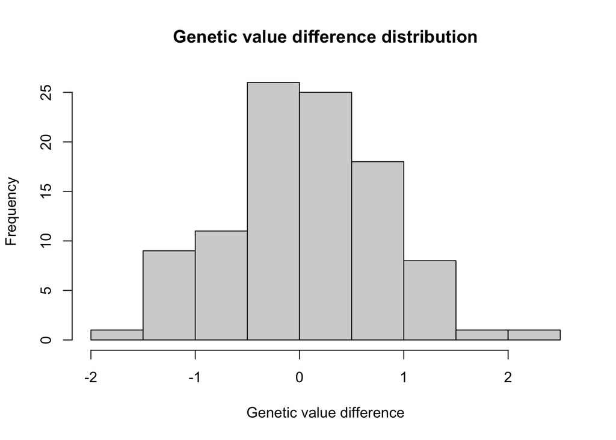

```r
hist(seed_vbw[,3], main= "Genetic value difference distribution", xlab="Genetic value difference")
```

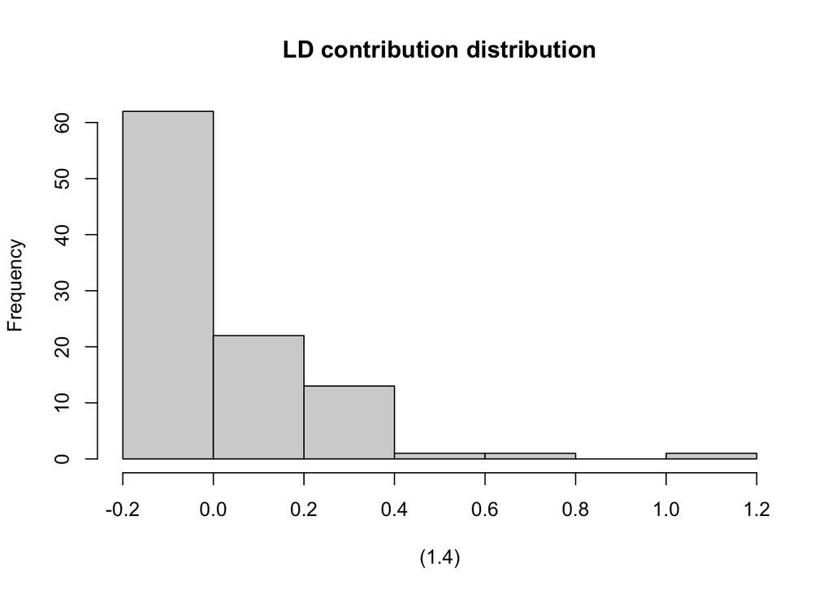

```r
hist(seed_vbw[,4], main= "LD contribution distribution", xlab="(1.4)")
```

```r
# which one gives you the largest LD contribution?
which(seed_vbw == max(seed_vbw[,4]), arr.ind = TRUE) #65   4
```

```
##      row col
## [1,]  65   4
```

```r
# which one gives you the lowest LD contribution?
which(seed_vbw == min(seed_vbw[,4]), arr.ind = TRUE) #84   4
```

```
##      row col
## [1,]  84   4
```

```r
# which one gives you the 0 LD contribution? i.e. the neutral evolution trait described in the paper.
# add new column for absolute value of the term 1.4, let's get the closest one to 0
abst4=abs(seed_vbw[,4])
new_vbw=cbind(seed_vbw, abst4)
which(new_vbw == min(new_vbw[,5]), arr.ind = TRUE) #  89  4
```

```
##      row col
## [1,]  89   4
## [2,]  89   5
```

#### Step3: the genetic value distribution for each trait

Let’s see what’s the genetic value distribution look like.

```r
seed1=99 #seed for freq
seed2_pos=65
seed2_neg=84
seed2_zero=89

set.seed(seed1) # keep this part same across P
# Draw allele frequency in an ancestral population prior to the divergence
# and drawn from a uniform distribution unif(0.001,0.999)
anc.frq <- runif(nloci, min=1e-3, max=0.999)

#set freq per ancestral population at each locus, given fst and human ancestral allele maf
f1 <- rep(NA, nloci)
f2 <- rep(NA, nloci)
for (s in 1:nloci) {
  # set allele frequencies for ancestries
  p.pop1 <- 0
  p.pop2 <- 0
  anc.frq <- runif(1, min=1e-3, max=0.999)
  #Balding-Nichol model, also make sure 0.01<frq<0.99, so rare variants are avoided
  while((p.pop1 <= 0.01 || p.pop1 >= 0.99) || p.pop2 <= 0.01 || p.pop2 >= 0.99){
    p.pop1 <- rbeta(1, anc.frq*(1-fst)/fst,(1-anc.frq)*(1-fst)/fst)
    p.pop2 <- rbeta(1, anc.frq*(1-fst)/fst,(1-anc.frq)*(1-fst)/fst)
  }
  f1[s] <- p.pop1
  f2[s] <- p.pop2
}
fbar = (f1+f2)/2
#fbar = pi*f1 + (1-pi)*f2
fdiff = f1 - f2 #freq difference

# simulate parental genotype based on frequency
geno1 <- matrix(rbinom(nloci*n, 2, f1), byrow=T, nrow=n, ncol=nloci)
geno2 <- matrix(rbinom(nloci*n, 2, f2), byrow=T, nrow=n, ncol=nloci)

###################  simulate effect size  ########################
#print("simulate effect size")

# Choose effect sizes from the standard normal distribution N(0, 1/2*f*(1-f))
bg = matrix(
  rnorm(nloci, 0, sd = sqrt(1/(2*nloci*fbar*(1-fbar)))),
  nrow = nloci, ncol = 1)

#standardize to remove stochasticity in realized values
bg = ((bg - mean(bg)) / sd(bg)) * sqrt(1/(2*nloci*fbar*(1-fbar)))


getPRS=function(seed2){
# random assign sign to each bg such that we have different distribution
set.seed(seed2)
bg_sign=sample(c(-1,1), nloci, replace=T) #for controling beta sign disribution

# For some fraction p of the loci, choose the effect direction to be such that
# the allele that is more frequent in population 1 has a positive effect.
# The rest are random.
# weak selection, use prob f1/(f1+f2) decide the sign of selected loci
# strong selection, use f1-f2 decide the sign of selected loci
if (p_sel == 0){
  bg_sel = bg* bg_sign
  }else{
    sel_index <- sample(c(1:nloci), size=round(nloci*abs(p_sel)), replace=F) # sample selected loci
    bg_sel = matrix(NA, nrow = nloci, ncol = 1)
    # selected index, change sign
    if (p_sel > 0){
      # weak selection
      bg_sel[sel_index] = abs(bg[sel_index]) * ((rbinom(nloci, 1, f1/(f1+f2))-0.5)*2)[sel_index]
      # strong selection
      #bg_sel[sel_index] = abs(bg[sel_index]) * (sign(fdiff))[sel_index]
      }else{
        bg_sel[sel_index] = abs(bg[sel_index]) * ((rbinom(nloci, 1, f1/(f1+f2))-0.5)*2)[sel_index] * (-1)
        #bg_sel[sel_index] = abs(bg[sel_index]) * (sign(fdiff))[sel_index] * (-1)
        }
      bg_sel[-sel_index] = bg[-sel_index]
}

# effect size of local ancestry
#bg_lanc = bg_sel * fdiff

###################  Calculate expected genetic variance in parental ########################
#print("Calculate expected genetic variance in parental")
# calculate expected value in parental groups
#vtotal.genic = sum(2* bg_sel^2 * fbar * (1-fbar))
#vbetween.genic = sum( bg_sel^2 * (f1-f2)^2) * 2 * 0.5 * 0.5
#vwithin.exp = sum(0.5*2*(bg_sel^2)*f1*(1 - f1) + 0.5*2*(bg_sel^2)*f2*(1 - f2))

###################  Calculate observed genetic variance in parental ########################
#print("Calculate observed genetic variance in parental")
# prs on causal variants
pop1_prs <- apply(geno1, MARGIN=1, FUN=indiv_prs, beta=bg_sel)
pop2_prs <- apply(geno2, MARGIN=1, FUN=indiv_prs, beta=bg_sel)
meta_prs = c(pop1_prs, pop2_prs)
return(meta_prs)
}

#function to plot
plotPRS=function(seed2, title){
meta_prs=getPRS(seed2)
df <- data.frame(
  pop=factor(rep(c("pop1", "pop2"), each=10000)),
  prs=meta_prs
  )
library(plyr)
library(ggplot2)
mu <- ddply(df, "pop", summarise, grp.mean=mean(prs))
#plot density plot
p<-ggplot(df, aes(x=prs, fill=pop)) +
  theme_classic() +
  geom_density(alpha=0.4)+
  xlab(c("Genetic value"))+
  geom_vline(data=mu, aes(xintercept=grp.mean, color=pop),
             linetype="dashed") +
  ggtitle(title)
return(p)}
```

Plot the PRS distribution of different traits.

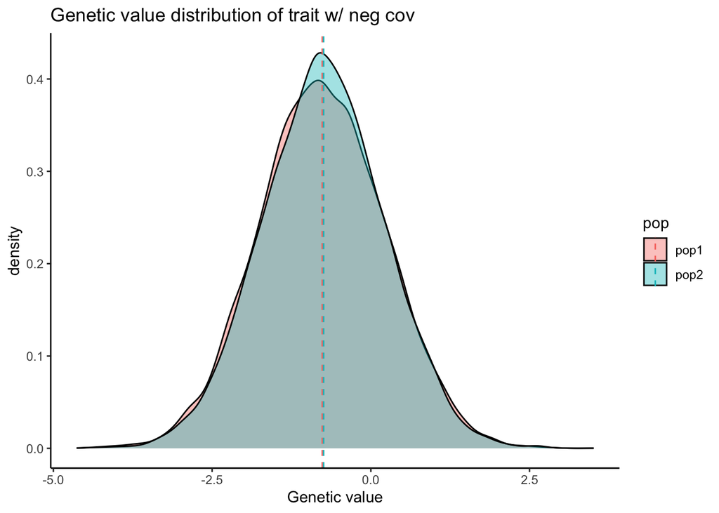

```r
plotPRS(seed2 = seed2_neg, title="Genetic value distribution of trait w/ neg cov")
```

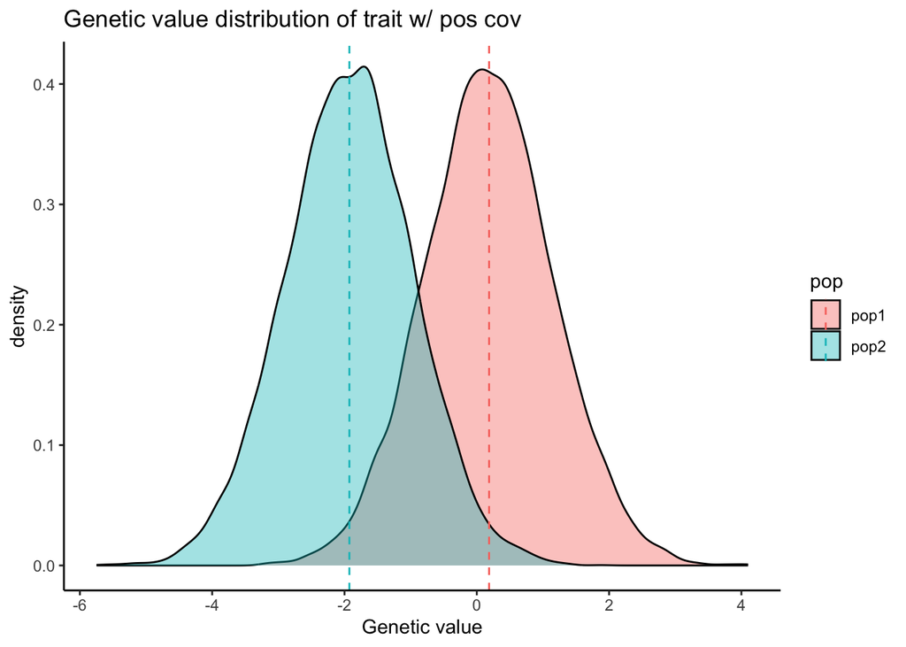

```r
plotPRS(seed2 = seed2_pos, title="Genetic value distribution of trait w/ pos cov")
```

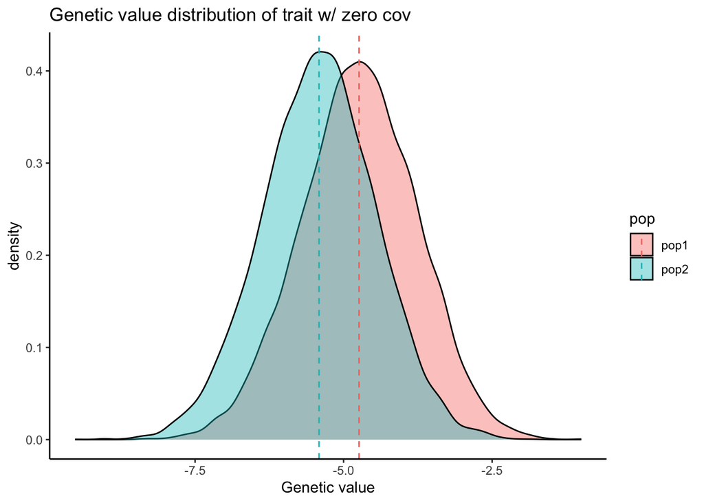

```r
plotPRS(seed2 = seed2_zero, title="Genetic value distribution of trait w/ zero cov")
```